# Orange Tree Predictor

2021-10-11

## The Data

Our application is based on the data frame ‘Orange’ from the package ‘datasets’.

```r
head(Orange)
```

```
##   Tree  age circumference
## 1    1  118            30
## 2    1  484            58
## 3    1  664            87
## 4    1 1004           115
## 5    1 1231           120
## 6    1 1372           142
```

It contains the age and the circumference of a number of orange trees.

## The Application - Overview

Our application has the following features:

- The app visualizes the data.
- The user can configure the plot.
- The app builds and visualizes a regression model for predicting the circumference of an orange tree from its age.
- The user can tune the model.
- The user can use the model to predict the circumference of an orange tree.
- The app includes a help page.

## The Model

We decided to use a basis spline to predict the circumference of an orange tree from its age.

Our model has two tuning parameters:

- The parameter ‘number of internal knots’ controls into how many pieces the range is decomposed (from 0 to 5). For n knots there are n+1 pieces.
- The parameter ‘degree’ controls the degree of the piecewise polynomials (from 1 to 5).

With the default settings (number of knots = 0 and degree = 1), the model is a linear model.

## The Application - Details

The following plot shows an example from the app:

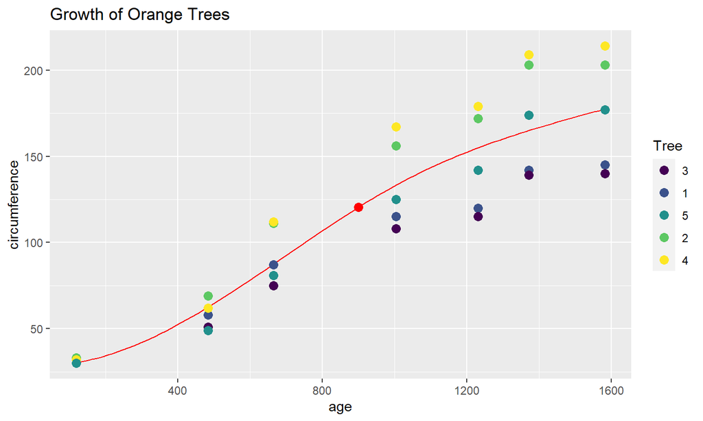